# An introduction to gexp package

## Quadratic response surface

Let’s omit matrix algebra as it is analogous to the one presented above. Considering now $\beta_2 = 2$ and $\beta_5 = 3$, we have the following result using the `gexp` package.

```r
crd_hb2 <- gexp(mu = 1,
                r = 2,
                err = matrix(rep(0,32),
                             nrow = 32),
                fe = list(f1 = c(3, 2, 0),
                          f2 = c(2, 3, 0)),
                fl = list(N = level,
                          P = level2),
                inte = c(2,1,0,1,8,0,0,0,0),
                contrasts = list(N = cont_crd,
                                 P = cont_crd2),
                type = 'FE')

summary(crd_hb2)
```

```
#> Database
#>    r  N P     Y1
#> 1  1  0 2     17
#> 2  2  0 2     17
#> 3  1  5 2    972
#> 4  2  5 2    972
#> 5  1 10 2   3727
#> 6  2 10 2   3727
#> 7  1 15 2   8282
#> 8  2 15 2   8282
#> 9  1  0 4     57
#> 10 2  0 4     57
#> 11 1  5 4   3542
#> 12 2  5 4   3542
#> 13 1 10 4  13727
```

[output cut: 19 more lines]

Below the simulation chart.

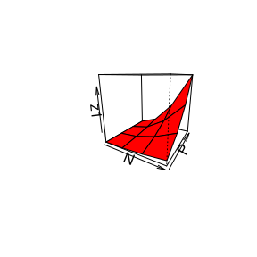

# Doing experiment planning

## Not interactive

### CRD

Let’s suppose that we are interested in planning a DIC with three treatments (default) and five repetitions (default). In this case, as we are not interested in simulating data, we can give any value to the effects of the treatments, because what matters is the arrangement of the treatments in the experimental units.

So, using the `gexp` package we have:

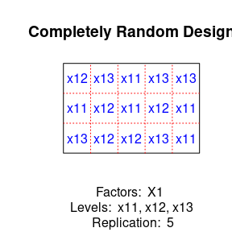

```r
crd_design <- gexp()
plot(crd_design)
```

### RCBD without repetition

Let us consider an RCBD in which the block is the very repetition of the experiment. Consider also three treatments (default) and three blocks (default).

With the `gexp` package we have:

```r
rcbd_designs <- gexp(r = 1,
                     design = 'RCBD')
```

Graphically, we have:

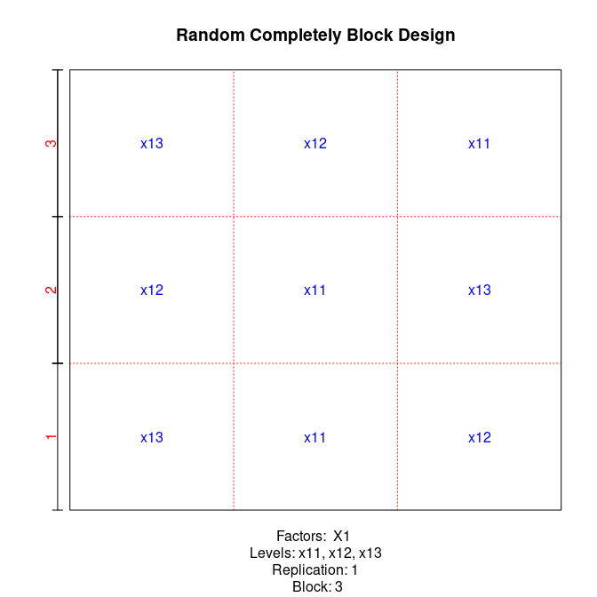

```r
plot(rcbd_designs)
```

### RCBD with repetition

Considering the same experiment previous, alternating the number of repetitions inside blocks. Let us now consider two replicates per block.

With the `gexp` package we have:

```r
rcbd_designc <- gexp(r = 2,
                     design = 'RCBD')
```

Graphically, we have:

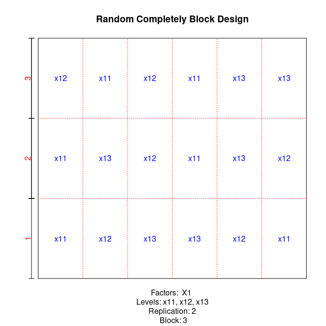

```r
plot(rcbd_designc)
```